# Training and test indices for Zinser data

Gregory Britten and Kristof Glauninger and Sangwon (Justin) Hyun

```r
knitr::opts_chunk$set(echo=TRUE, warning=FALSE,
                      message=FALSE, eval=TRUE, cache=TRUE,
                      fig.width=20, fig.height=20)
```

Load packages and set the working directory.

```r
library(ncdf4)
library(viridis)
library(fields)
library(rstan)
options(mc.cores = parallel::detectCores())
## setwd('d:/dropbox/working/bayesian-matrixmodel/')
repodir = '/home/shyun/repos/matrix-model/' ## The directory of your repository.
setwd(repodir)
```

# Visualize Zinser data

Take the latest calibrated Zinser data. In the top plot, there are $m=52$ size categories, and $t=0, \cdots, 24$ time points – 24 time points at 2-hour increments over two days, plus one time point for t=0. The colors and thickness of each line shows, from blue+thin to red+thick, the small to large size classes. The sunlight `par` variable is overlaid (out of scale) as well.

```r
##' Helper to open Zinser data.
##' @param filename NC file filename, like
##'   \code{"data/Zinser_SizeDist_calibrated-52-12.nc"}.
##' @return List containing data \code{obs} (T x m matrix), \code{time} (T
##'   length list of minutes passed since the beginning), \code{num_sizeclass}
##'   (Number of size classes, or m), and \code{v} (left-hand-side border of
##'   size classes).
open_zinser <- function(filename = "Zinser_SizeDist_calibrated-52-12.nc",
                        datadir = "data"){

  ## Read data.
  ## "data/Zinser_SizeDist_calibrated-52-12.nc"
  nc <- nc_open(file.path(datadir, filename))
  PAR   <- ncvar_get(nc,'PAR') ## Sunlight
  w_obs <- ncvar_get(nc,'w_obs') ## Data

  ## List variables in the nc file.
  names(nc$var)

  ## What are these?
  m <- ncvar_get(nc,'m') ## Number of size classes

  ## Time (in number of minutes since the beginning)
  time  <- ncvar_get(nc,'time')

  ## Size classes
  delta_v_inv <- ncvar_get(nc,'delta_v_inv')
  v_min       <- ncvar_get(nc,'v_min')
  delta_v <- 1/delta_v_inv
  v <- v_min * 2^(((1:m) - 1) * delta_v)

  ## Name of w_obs
  rownames(w_obs) = time
  colnames(w_obs) = v

  ## Return
  return(list(obs = w_obs,
              time = time,
              num_sizeclass = m,
              v = v,
              nc = nc,
              PAR = PAR))
}
```

You can see that the growth and division is in concordance with the sunlight variable `par`, over the two day period of the data.

The bottom plot is also another version of the data at a different number of size classes. There are half as many size categories (26 of them), and the same number of ($25$) time points.

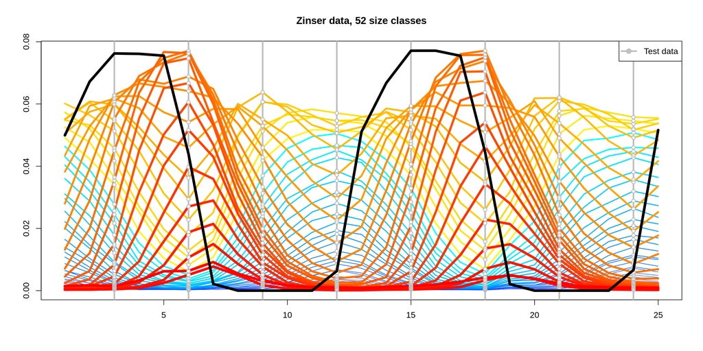

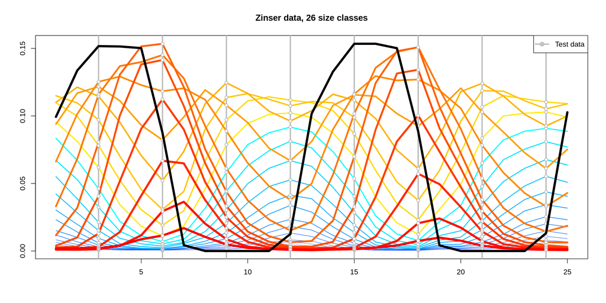

```r
## Retrieve data
for(filename in c("Zinser_SizeDist_calibrated-52-12.nc",
                  "Zinser_SizeDist_calibrated-26-6.nc")){

  ## Load data
  dat = open_zinser(filename)

  ## Plot *calibrated* Zinser data.
  ncat = ncol(dat$obs) ## alternatively, ncat = dat$num_sizeclass
  cols = colorRamps::blue2red(ncat)
  ylim = range(dat$obs)
  matplot(dat$obs, col = cols, lwd = seq(from = 0.1, to = 5, length = ncat),
          lty = 1, type = 'l', ylab = "", xlab = "")
  title(main = paste0("Zinser data, ", ncat, " size classes"))


  ## Making i_test
  d = 3
  i_test = rep(0, length(dat$time))
  i_test[seq(from=d, to=length(dat$time), by=d)] = 1

  ## Add grey regions for the time points that we're going to leave out.
  cex = 1
  abline(v = which(i_test == 1), col='grey', lwd=3, lty=1)
  for(ii in which(i_test == 1)){
    points(x=rep(ii, dat$num_sizeclass), y=dat$obs[ii,], pch=16, col="grey", cex=cex)
    points(x=rep(ii, dat$num_sizeclass), y=dat$obs[ii,], pch=16, col="white", cex=cex * 0.7)
    points(x=rep(ii, dat$num_sizeclass), y=dat$obs[ii,], pch=1, col="grey", cex=cex)
  }

  ## Add sunlight
  scpar = scale(dat$PAR)
  scpar = scpar - min(scpar)
  scpar = scpar / max(scpar) * max(dat$obs)
  lines(scpar, lwd = 5)

  ## Add legend
  legend("topright", lwd=3, col='grey', pch=1, legend="Test data")
}
```

# Training and test indices for Zinser data

The `i_test` variable is a numeric vector which contains 0’s an 1’s, and the time points left out shown the grey vertical lines (and empty grey points). The test data is every 3rd data point, out of $t=0 \cdots 24$:

0 0 1 0 0 1 0 0 1 0 0 1 0 0 1 0 0 1 0 0 1 0 0 1 0

We’ll save these indices in either an `.Rdata` file or a `.csv` file, each named:

`"Zinser_SizeDist_calibrated-52-12-itest.Rdata"` `"Zinser_SizeDist_calibrated-52-12-itest.csv` `"Zinser_SizeDist_calibrated-26-6-itest.Rdata"` `"Zinser_SizeDist_calibrated-26-6-itest.csv"`

These files are written into the `data` directory:

```r
filenames = c("Zinser_SizeDist_calibrated-52-12",
              "Zinser_SizeDist_calibrated-26-6")
for(filename in filenames){
  dat = open_zinser(paste0(filename, ".nc"))
  datadir = file.path(repodir, "data")
  save(i_test, file = file.path(datadir, paste0(filename, "-itest.Rdata")))
  write.table(i_test, file = file.path(datadir, paste0(filename, "-itest.csv")),
              row.names = FALSE, col.names = FALSE)
}

## Reading it in:
i_test = unlist(read.csv(file = file.path(datadir, paste0(filenames[1], "-itest.csv")),
                         header = FALSE))
```

# Stan code for model fitting

Lastly, using this vector `itest`, from now on, **you should experiment on model variations only on the training points**, and **evaluate on the test points**. Compared to existing scripts, the key difference is in the use of variable `log_like_test` – we are explicitly looking for models that yield higher out-of-sample likelihoods.

Here is roughly what to do in Stan. In fitting (training), only the training points `i_test[it]==0` are used. In calculating the test score, use only the time points for which `i_test[it]==1`.

```
model {
    real diff;

    // priors
    delta_max ~ uniform(0.0,1440.0/dt); // T[0.0,1440.0/dt];
    gamma_max ~ uniform(0.0,1440.0/dt);
    E_star ~ normal(3000.0,10.0);
    sigma ~ exponential(1000.0);

    // fitting observations
    for (it in 1:nt_obs){
        diff = 0.0;
        if(i_test[it]== 0){
        for (iv in 1:m){
            diff += fabs(mod_obspos[iv,it] - obs[iv,it]);
        }
        diff = diff/sigma;
        diff ~ normal(0.0, 1.0) T[0,];
    }
    }
}
generated quantities{
    real log_like_test = 0;
    {real diff;
    for(it in 1:nt_obs){
        if(i_test[it] == 1){
            diff = 0.0;
            for(iv in 1:m){
                diff += fabs(mod_obspos[iv,it] - obs[iv,it]);
            }
            diff = diff/sigma;
            log_like_test += normal_lpdf(diff | 0.0, 1.0);
        }
    }
    log_like_test = log_like_test/n_test;
    }
}
```

# Other notes

1. Zinser model evaluation is fishy (one-day-long iterations, using previous day’s *real* data and not the model)
2. How to rerun Zinser model to get fairer model fit? This is in order to compare our model to theirs.
3. For the Seaflow data, and within the time frame (e.g. 1 day) we will apply the model to, which time points do we leave out as a “test” set?

# References